# Critical Line Method

Pasi Kytölä

27.7.2021

## 1. Johdanto

Harry Markowitz kehitti 1950-luvulla menetelmän sijoitusten hajauttamiseen. Sijoitusten hajauttaminen oli ollut käytössä jo kauan ennenkuin Markowitz menetelmänsä kehitti, mutta formaalia analyysia ei ymmärtääkseni ollut [1] kehitetty. Markowitz antaa yhtälaisen kunnian Andrew Roylle, mutta juuri Markowitz on saanut työstään taloustieteen Nobel palkinnon.

Menetelmä löytää sijoitusten kesken sellaiset sijoitusten kombinaatiot (yhdistelmät), joille ei löydy toista kombinaatiota, jolla olisi pienempi tuoton keskihajonta samalla tuoton tasolla tai toisinpäin suurempi tuotto samalla keskihajonnalla. Tässä sijoitukselle synonyymi on yritysten osakkeet, joita kaupitellaan pörsseissä. Talouden kielessä kombinaatioita kutsutaan monesti yleisesti *portfolioksi* ja Markowitzin menetelmällä jäljitettyjä portfoliolla kutsutaan *tuoton keskiarvo-keskihajonta tehokkaiksi*. Tehokkaiden portfolioiden joukkoa kutsutaan *tehokkaaksi rintamaksi* johtuen siitä, että kun nämä portfoliot esitetään tuoton keskiarvo-keskihajonta koordinaatistossa, näyttää tehokkaiden porfolioiden kuvaja muodostavan eräänlaisen rintaman, jonka toiselle puolella ei ole muita kombinaatioita. Menetelmä, joka jäljittää tehokkaat kombinaatiot kutsutaan nimellä Critical Line Method (CLM) ja yleisesti koko tätä prosessia taidetaan kutsua nimellä Mean-Variance Analysis (MVA). Nimi johtunee siitä, että Markowiz havaitsi sopiviksi tunnusluvuiksi tuoton mittarina tuoton aritmeettisen keskiarvon (tai odotusarvon, jos kyse ei ole historiallisista tuotoista vaan subjektiivisista tuotto-odotuksista) ja tuoton vaihtelun mittarina tuoton varianssin/kovarianssit. Varianssia menetelmässä käytetään laskuvaiheessa ja lopputulokset esitetään keskihajonnan avulla, koska johtuen varianssin laskutavasta, se ei ole suoraan käyttökelpoinen vertailuissa toisin kuin keskihajonta. Osiin pilkottuna MVA sisältää ensimmäiseksi tehokkaiden kombinaatioiden löytämisen, toiseksi näiden portfolioiden tuotto-vaihtelu parien esittäminen sijoittajalle, kolmanneksi sijoittaja valitsee näistä huolellisesti itselleen sopivan parin, ja lopuksi sijoittaja saa tätä paria vastaavan portfolion osakkeiden painokertoimet. R koodini liittyy ensimmäiseen vaiheeseen, eli tehokkaiden kombinaatioiden jäljittämiseen. CLM menetelmä on ymmärtääkseni kehitetty 1956 nurkilla [2] ja se on käytössä vuoden 1959 kirjassa [3], johon tämä työ perustuu. Robert C. Merton esitti myöhemmin [4] samaan ongelmaan toisenlaisen lähestymistavan, jolla ymmärtääkseni päästään samaan lopputulokseen.

Markowitzin mukaan menetelmän käyttäminen edellyttää, että sijoittaja on riskiä kaihtava ja noudattaa (odotetun) hyödyn teoriaa päätöksenteossa epävarmuuden vallitessa. Riskiä kaihtava sijoittaja valitsee kahdesta saman tuoton tarjoavasta osakkeesta vähemmän riskisen ja toisin kuin vain tuottoa maksimoiva sijoittaja, joka päätyy portfolioon jossa on vain yhtä osaketta, sitä jolla on suurin tuotto, niin hyötyä maksimoiva sijoittaja on kiinnostunut myös riskistä ja se johtaa siihen, että hyöty ei maksimoidu välttämättä tuoton maksimoituessa ja sellainen toiminta johtaa hajautukseen. Odotetun hyödyn maksimointi on riittävä ja välttämätön ehto MVA menetelmän hyödyntämiseksi. Markowitzin mukaan tuottojen normaalisuus ei ole välttämätön menetelmän toimivuudelle [5]. Hyödyn selvittämiseksi on muodostettava hyötyfunktio, joka yrittää esittää hyödyn tuoton funktiona. Siinä tarvitaan ymmärtämystä todennäköisyyslaskennasta ja rationaalisesta päätöksenteosta epävarmuuden vallitessa. Mikäli nämä eivät ole tuttuja sijoituspalvelua tarjoavalle henkilölle tai sijoittajalle, on tehtävä haastava ja aikaa vievä. MVA menetelmän pihvi ymmärtääkseni on, että valitessaan huolellisesti itselleen sopivan portfolion tehokkaalta rintamalta, se johtaa suunnilleen useiden konkaavien (riskiä kaihtavan sijoittajan hyötyfunktion muoto) hyötyfunktioiden maksimointiin ilman, että sijoitusneuvojalla tai sijoittajalla on ymmärtämystä odotetun hyödyn konseptista [6]. Hyötyfunktio voi olla myös hankala maksimoida.

Kuvailen seuraavaksi osakkeet, jota Markowitz käyttää kirjassaan kandidaatteina portfolioiden komponenteiksi. Olen naputellut osakkeiden tuotot eri vuosilta data.txt-tiedostoon (löytyy R-kansiosta) vuoden 1959 kirjasta.

## 2. Kirjan (1959) aineiston kuvailu

Aineisto koostuu yhdeksän yrityksen osakkeen tuotoista vuosilta 1937-1954. Kunkin vuoden tuotto on

(osakkeen päätöshinta vuoden viimeisenä markkinapäivänä) miinus  
(osakkeen päätöshinta edellisen vuoden viimeisenä markkinapäivänä) plus  
(osingot vuodelta) jaettuna  
(osakkeen päätöshinta edellisen vuoden viimeisenä markkinapäivänä).

Esimerkikkinä vuoden 1948 tuotto on ${\frac {(päätöshinta,\ 1948)-(päätöshinta,\ 1947)+(osingot,\ 1948)}{(päätöshinta,\ 1947)}}$.

Tämän verran sijoittaja olisi tienannut tai hävinnyt, jos hän olisi sijoittanut yhden dollarin vuoden 1947 lopussa, kerännyt osingot vuodelta 1948 ja myynyt viimeisenä markkinapäivänä 1948. Tappio ilmaistaan negatiivisena tuottona.

### 2.1. Kirjan osakkeiden tuotot graafisesti vuosilta 1937-1954

Keskihajonta on populaatiokeskihajonta (ei otoskeskihajonta), koska Markowitz käyttää tätä tapaa kirjassaan. Arvot vastaavat kirjasta löytyviä.

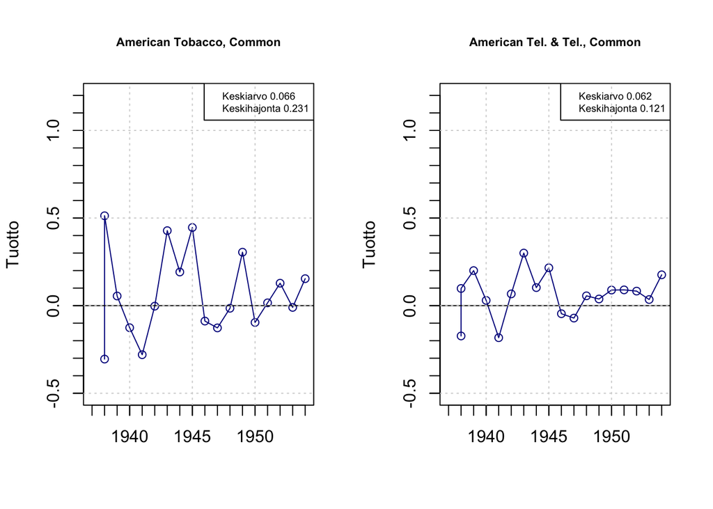

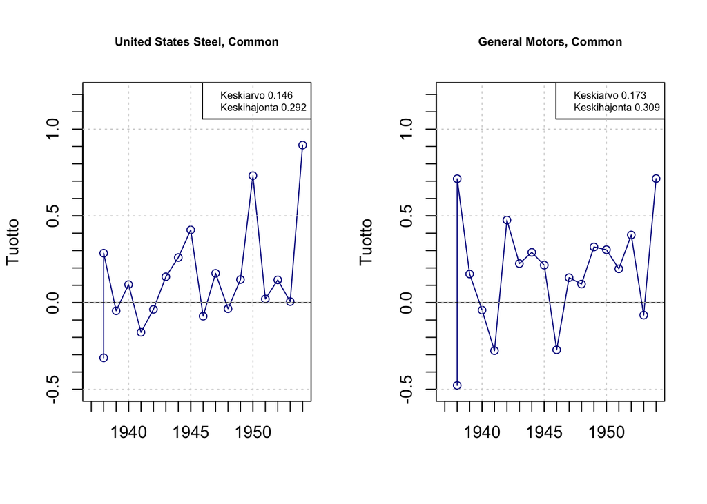

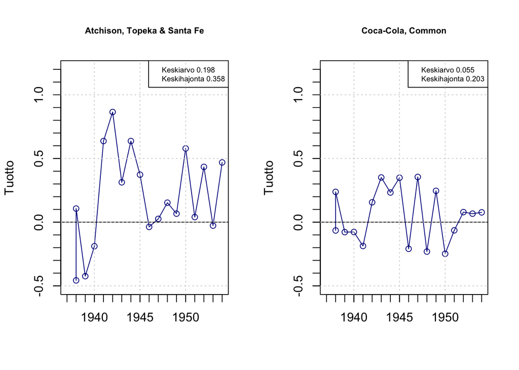

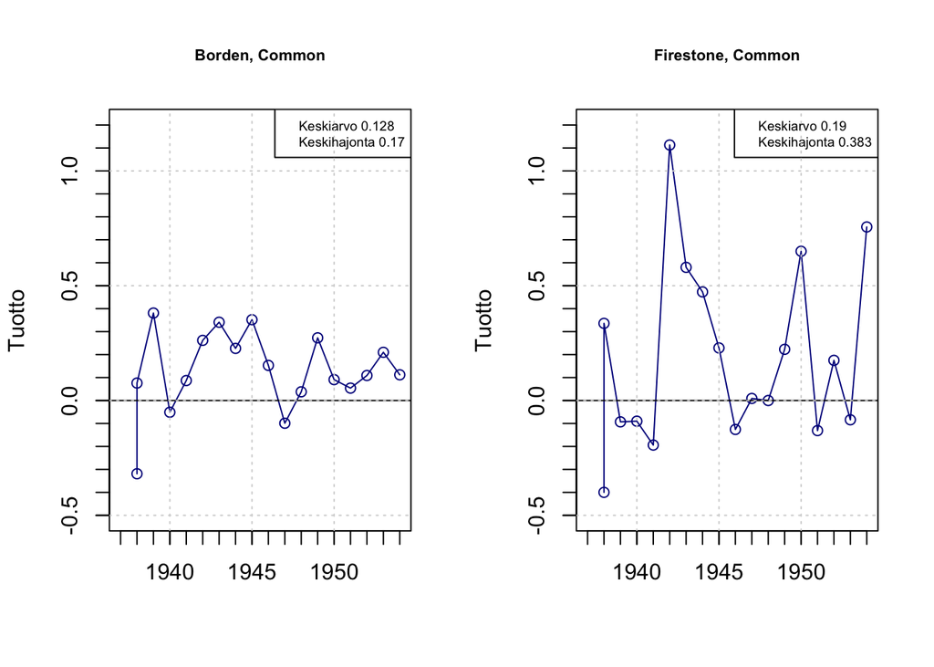

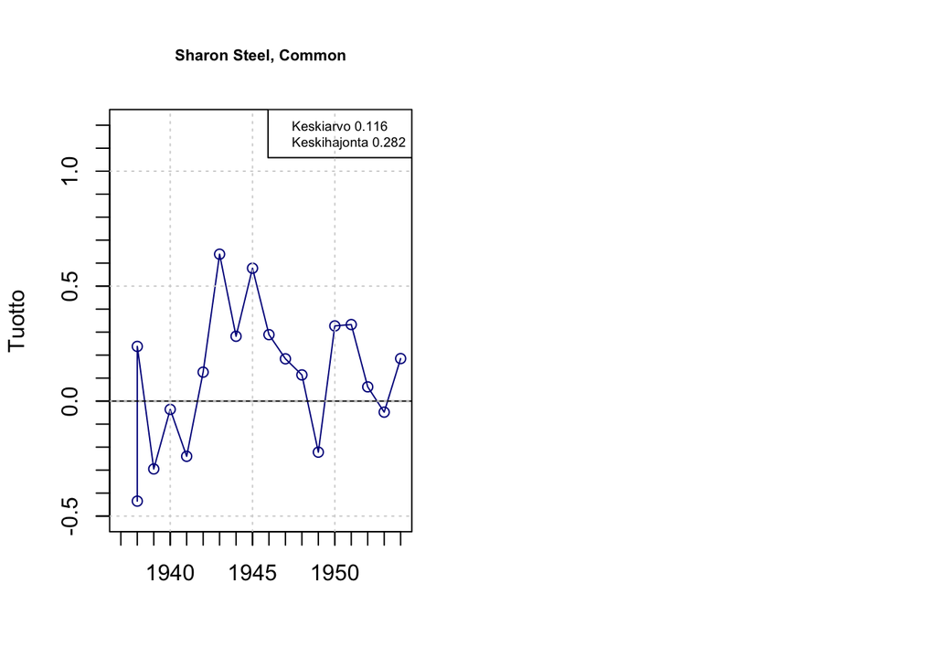

Vaikka yksittäisten osakkeiden tuotto vaihtelisikin vuosien välillä huomattavasti, kuten yllä olevasta havaitaan, niin useista osakkeista koostuvan kombinaation tuoton vaihtelu voi olla alhainen. Tähän liittyi se oivallus, että kun kaikki osakkeet eivät korreloi keskenään vahvasti, on jonkun tuotto jonain vuonna positiivinen ja toisen vähemmän positiivinen tai negatiivinen. Valitsemalla mukaan esimerkiksi eri toimialoilla toimivia yrityksiä, voidaan saada niiden muodostaman portfolion tuoton vaihtelu mitattuna keskihajonnalla pienemmäksi kuin yksittäisten osakkeiden vaihtelu.

### 2.2. Osakkeiden tuottojen väliset riippuvuudet

Oheinen korrelaatiomatriisi esittää osakkeiden väliset tuottojen korrelaatiot ja pisteparvet. Voidaan havaita erisuuria riippuvuuksia osakkeiden välillä.

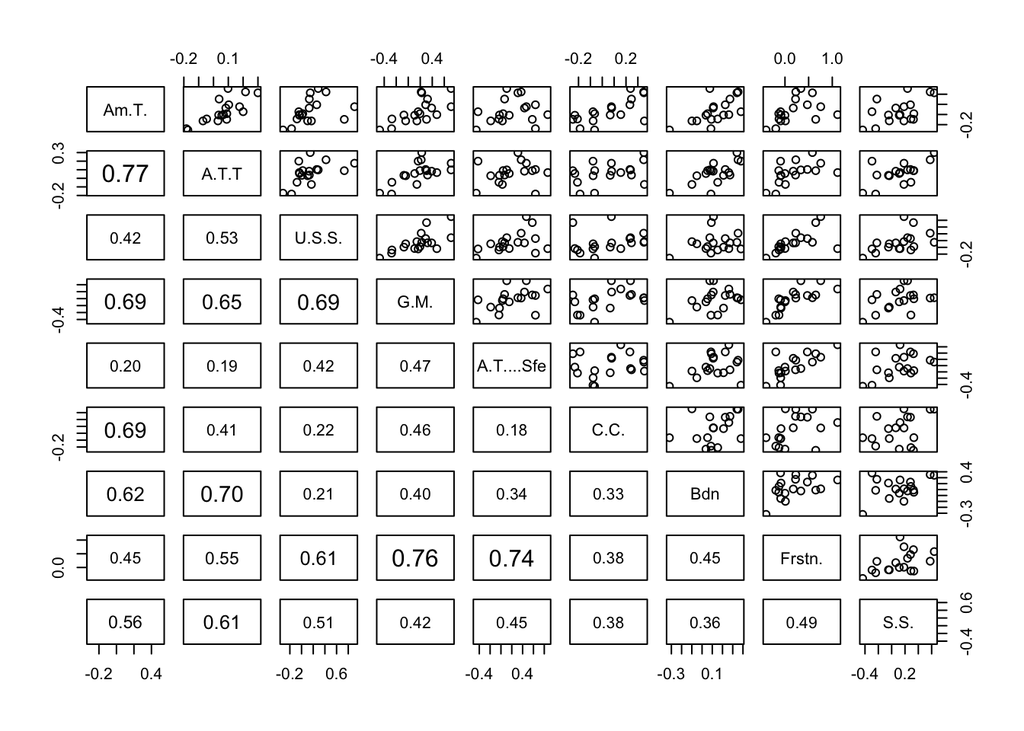

Kirjasta esimerkkinä kahdesta osakkeesta kombinaatio siten, että Coca-Cola osakkeen osuus 0.8 ja A.T. & Sfe osaketta on loput 0.2. Kuviosta näkee, miten kombinaation tuoton vaihtelu on tasaisempi kuin yksittäisten osakkeiden vaihtelu.

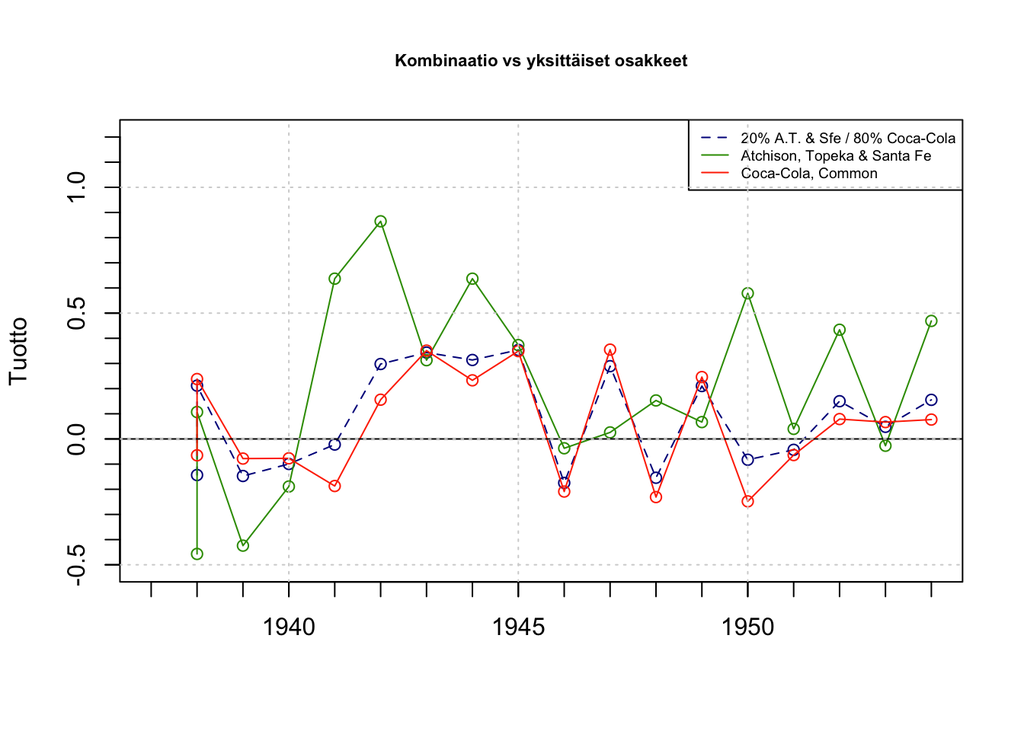

Kombinaatiolla on suurempi tuoton aritmeettinen keskiarvo ja pienempi keskihajonta kuin Coca-Cola osakkeella.

| Osakkeet | Tuoton keskiarvo | Tuoton keskihajonta |
| --- | --- | --- |
| Kombinaatio 20% A.T. Sfe / 80% Coca-Cola | 0.084 | 0.189 |
| A.T. Sfe, Common | 0.198 | 0.358 |
| Coca-Cola, Common | 0.055 | 0.203 |

Tästä sitten heräsi luonnollisesti kysymyksiä. Olisiko olemassa joku toinen yhdistelmä, jossa olisi vielä suurempi keskimääräinen tuotto ja pienempi vaihtelu kuin edellinen. Tai ehkäpä suurempi tuotto ja sama vaihtelu. Tai sama tuotto, mutta pienempi vaihtelu.

## 3. Tehokkaan rintaman määrittäminen

CLM menetelmä etsii toisiaan seuraavat kriittisen suorien segmentit iteratiivisesti. Jokaisella kierroksella, eri kriittisen suoran osalla, osa osakkeista on sisällä/mukana (in) ja osa ulkona (out). Menetelmä etenee pitkin toisiaan seuraavia kriittisten suorien osia, jotka eroavat toisistaan mukana olevien osakkeiden osalta. Kun kriittistä suoraa vaihdetaan, lisätään tai poistetaan yksi osake kerrallaan. Suoraa vaihdetaan kriittisten suorien leikkauskohdissa. Se mille suoralle siirrytään, valitaan $\lambda_E$ muuttujan perusteella. Suoritus lähtee siitä kombinaatiosta, jolla on suurin tuotto ja etenee kohti vähenevää varianssia.

### 3.1. Menetelmä geometrisesti kolmen osakkeen kesken

Yhteenvetona kuten se on kirjassa suurinpiirtein esitetty.

$X_1$ on osakkeeseen 1 sijoitettu osuus, $X_2$ on osakkeeseen 2 sijoitettu osuus ja $X_3$ on osakkeeseen 3 sijoitettu osuus. Näiden kolmen osakkeen kombinaatiot voidaan esittää kaksiulotteisessa karteesisessa koordinaatistossa, koska $X1+X2+X3=1$, josta saadaan $X3=1-X1-X2$:

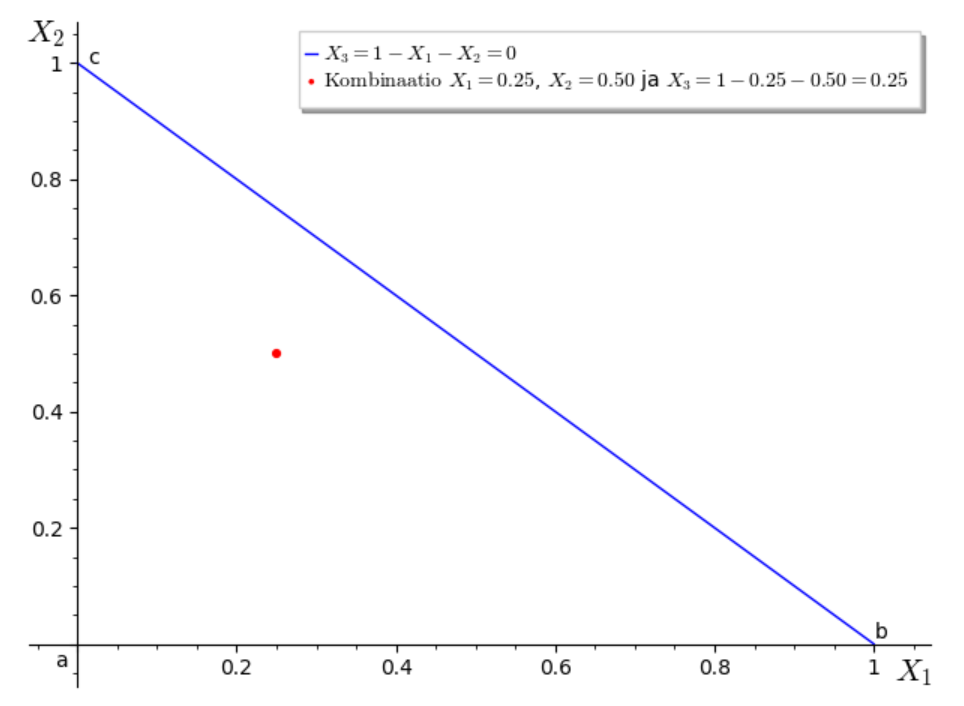

Kuva 1: Kolme osaketta kaksiulotteisessa koordinaatistossa.

Koska rajoitteena on $X_1+X_2+X_3=1$, missä $X_1 \geq 0, X_2 \geq 0 ja X_3 \geq 0$, niin kelvolliset kombinaatiot ovat kolmion abc sisällä. Muitakin rajoitteita voi olla, mutta tässä harjoitustyössä käsittelen vain edellä mainitut.

Kombinaation odotettu tuotto/keskiarvo on $\operatorname {E}=\sum _{j=1}^{n}X_j\mu_j=\mu^{'}X$ ja varianssi $\operatorname {V}=\sum _{i=1}^{n} \sum _{j=1}^{n} X_iX_j\sigma_{ij}$, missä $\sigma$ merkitsee varianssia tai kovarianssia. Tuotot ovat suoria ja 2. astetta olevat varianssiyhtälöt ellipsisysteemejä.

Allaolevassa kuviossa on esitettynä suorat, jotka esittävät kombinaatiota, joiden tuotot ovat 0.05, 0.06, 0.07, 0.08, 0.09 ja 0.10. Kelvolliset kombinaatiot ovat edelleen kolmion abc sisäpuolella. Suorien edustamien kombinaatioiden tuotto suurenee, kun siirrytään vasemmalta oikealle mutta suoralla ollessa tuotto pysyy samana (tässä esityksessä siis näin, muutoin ei sen näin tarvitse olla):

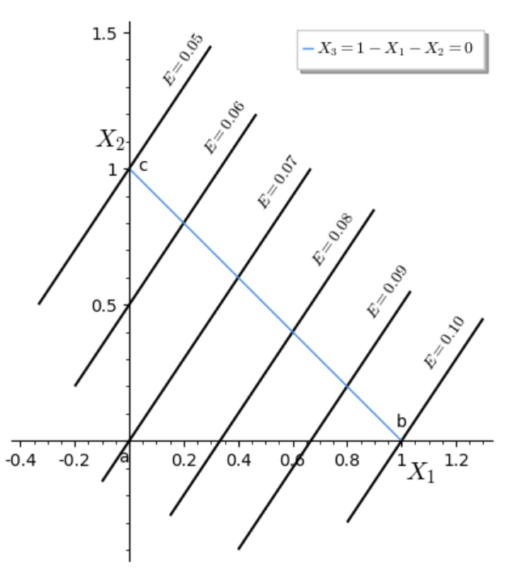

Kuva 2: Tuottojen suoria.

Allaolevassa kuviossa on ellipsit, jotka esittävät kombinaatiota, joiden varianssit ovat 0.01, 0.02, 0.03, ja 0.04. Kelvolliset kombinaatiot ovat edelleen kolmion abc sisäpuolella. Ellipsien edustamien kombinaatioiden varianssi kasvaa, kun siirrytään suuremmaksi ellipsiksi. Eli ellipsi jonka varianssi on 0.01 sisältyy ellipsiin, jonka varianssi on 0.02, joka taas sisältyy ellipsiin, jonka varianssi on 0.03 ja niin edelleen:

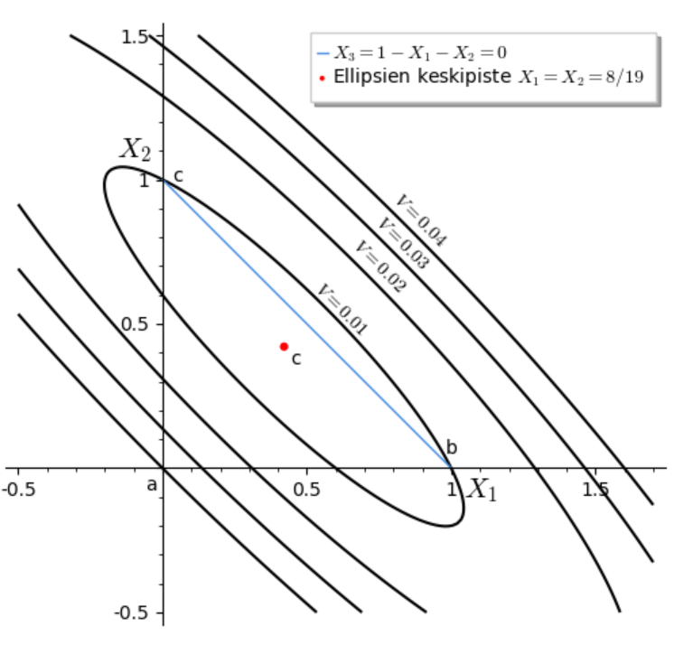

Kuva 3: Varianssien ellipsisysteemejä.

Pienin varianssi on ellipsisysteemin keskipisteessä c.

Allaolevassa kuviossa on yhdistetty tuottojen suorat sekä varianssien ellipsisysteemit. Pisteessä, missä tuottotaso sivuaa varianssiellipsiä, on pienin varianssi sille tuottotasolle:

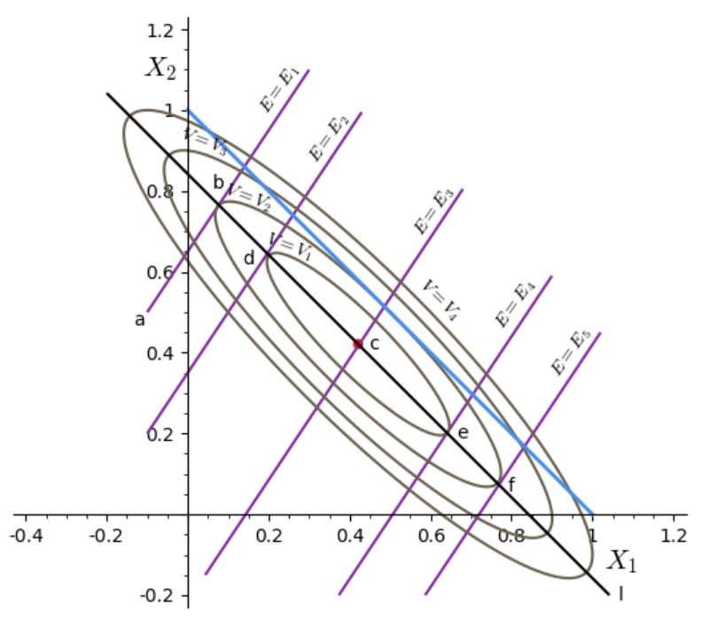

Kuva 4: Tuottosuorat ja varianssit.

Allaolevassa kuvassa piste c esittää kombinaatiota jolla on pienin varianssi kaikkien (kelvollisten ja ei-kelvollisten) kombinaatioiden joukossa. Kuvassa se on kelvollinen. Piste $\bar{X}$ on kombinaatio, jolla on suurin tuoton odotusarvo/keskiarvo kaikkien kelvollisten kombinaatioiden joukossa. Paksunnetut viivat l ja $X_1$ akselin pätkä ovat kriittisiä suoria. Markowitz argumentoi, että paksu suora $ca\bar{X}$ esittää tehokkaita kombinaatioita ja että kombinaatio on tehokas, jos ja vain jos se on paksulla suoralla:

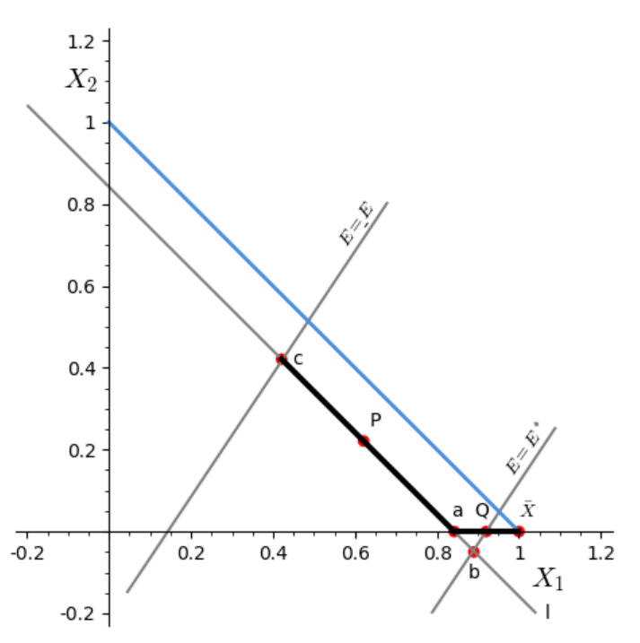

Kuva 5: Kriittiset suorat.

### 3.2. Menetelmä geometrisesti neljällä osakkeella

Kun otetaan mukaan neljäs osake, johon sijoitettu osuus on $X_4$. Näiden neljän osakkeen kombinaatiot voidaan esittää kolmiuloitteisessa karteesisessa koordinaatistossa, koska $X1+X2+X3+X4=1$, josta saadaan $X_4=1-X_1-X_2-X_3$.

Kelvolliset kombinaatiot ovat tetraedrin abcd sisällä $\mathbb{R}^3$ aliavaruudessa, koska rajoitteena on $X_1+X_2+X_3+X_4=1$ sekä $X_1\geq0, X_2\geq0, X_3\geq0 ja X_4\geq0$:

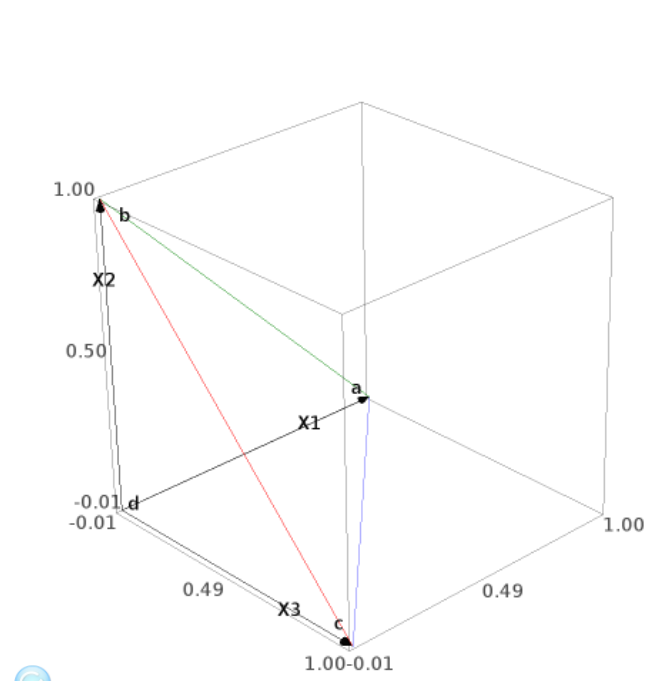

Kuva 6: Neljän osakkeen tilanne.

Useampaa kuin neljää osaketta on hankala esittää geometrisesti, mutta menetelmä toimii samoin useampiulotteisessa avaruudessa. Alla olevassa esityksessä osakkeita on yhdeksän ja kymmenentenä käteinen.

### 3.3. Yleinen kuvaus

R koodi noudattelee allaolevaa logiikkaa. Se etsii toisiaan seuraavat kriittisen suorien segmentit iteratiivisesti. Jokaisella kierroksella, eri kriittisen suoran osalla, osa osakkeista on sisällä/mukana (in) ja osa ulkona (out). Menetelmä etenee pitkin toisiaan seuraavia kriittisten suorien osia, jotka eroavat toisistaan mukana olevien osakkeiden osalta. Kun kriittistä suoraa vaihdetaan, lisätään tai poistetaan yksi osake kerrallaan. Suoraa vaihdetaan kriittisten suorien leikkauskohdissa. Tätä risteyskohtaa kutsutaan kulmaportfolioksi. Se mille suoralle siirrytään, valitaan $\lambda_E$ muuttujan perusteella. Suoritus lähtee siitä kombinaatiosta, jolla on suurin tuotto ja etenee kohti vähenevää varianssia.

### 3.4. Tarvittavat matriisit ja vektorit

Osakkeiden painot esitetään pystyvektorina $\text{X}=\begin{bmatrix}X_{1}\\.\\.\\.\\X_{n}\end{bmatrix}$, missä $X_j$ on osuus, joka on sijoitettu osakkeeseen $j$. Oletetaan, että kukin $X_j \geq0$.

Jokaiselle $X_j$ voi olla rajoitteita

$a_{11}X_1+a_{12}X_2+a_{13}X_3+...+a_{1n}X_n=b_1,\\ a_{21}X_1+a_{22}X_2+a_{23}X_3+...+a_{2n}X_n=b_2,\\ ...\\ a_{m1}X_1+a_{m2}X_2+a_{m3}X_3+...+a_{mn}X_n=b_m,\\ a_{ij}\in \mathbb{R}.$

Nämä voidaan esittää muodossa $A\text{X}=\text{b}$, missä $\text{A}$ on m x n matriisi ja $\text{b}$ on m elementtinen pystyvektori.

Tässä työssä ainoa rajoite, sen lisäksi, että kukin $X_j \geq0$, on $\sum \operatorname {X}_j=1$. Se voidaan esittää yhdellä $\text{A}$ matriisin rivillä, $\text{m}=1$, $a_{11}=a_{12}=a_{13}=\cdots=a_{1n}=1$ ja $b_1=1$.

Merkitään koko kombinaation tuoton odotusarvoa tai keskiarvoa $\operatorname {E}$, $\mu$ kirjaimella kaikkien odotusarvojen tai keskiarvojen pystyvektoria ja $\mu^{'}$ sen transpoosia.

Kombinaation odotettu tuotto/keskiarvo on $\operatorname {E}=\sum _{j=1}^{n}X_j\mu_j=\mu^{'}X$.

Kombinaation varianssi on $\operatorname {V}=\sum _{i=1}^{n} \sum _{j=1}^{n} X_iX_j\sigma_{ij}=\begin{bmatrix}X_{1}&X_{2}&.&.&.&X_{n}\end{bmatrix}\begin{bmatrix}\sigma_{11}&\sigma_{12}&.&.&\sigma_{1n}\\.&.&&&.\\.&.&&&.\\.&.&&&.\\\sigma_{n1}&\sigma_{n2}&.&.&\sigma_{nn}\end{bmatrix}\begin{bmatrix}X_{1}\\.\\.\\.\\X_{n}\end{bmatrix}$, missä $\sigma_{ij}$ on osakkeiden i ja j välisen tuoton kovarianssi ja kun $i=j$, niin osakkeen varianssi. Merkitään varianssi-kovarianssi matriisia $C$, jolloin $V=X'CX$, missä $X'$ on $X$ pystyvektorin transpoosi. $C$ on symmetrinen, koska $\sigma_{ij}=\sigma_{ji}$. Huom: $\sigma$ ei siis merkitse tässä keskihajontaa vaan varianssia tai kovarianssia. Pidättäydyn kirjan merkintätavassa.

Ohjelma etsii siis ensin sen kombinaation, jolla on suurin tuotto. Koska ainoa rajoite on $\sum \operatorname {X}_j=1$, niin tämä kombinaatio koostuu käytännössä siitä osakkeesta jolla on suurin tuotto. siitä edetään kohti pienenevää varianssia pitkin eri kriittisen suorien segmenttejä.

Kriittiset suorat määritetään seuraavien vektoreiden ja matriisien avulla.

Matriisi $M=\begin{bmatrix}C&A'\\A&0\end{bmatrix}$, missä 0 on m x m nolla matriisi. M on symmetrinen.

R on (m+n) elementtinen pystyvektori, jossa on ensin n elementtinen pystyvektori, jonka alkiot ovat nollia ja sitten m elementtinen pystyvektori b,

$\operatorname {R}=\begin{bmatrix}0\\.\\.\\.\\0\\b_{1}\\.\\.\\.\\b_{m}\end{bmatrix}=\begin{bmatrix}\text{0}\\\text{b}\end{bmatrix}$.

S on (m+n) elementtinen pystyvektori, jossa on ensin n elementtinen pystyvektori $\mu$ ja sen alla m elementtinen pystyvektori, jonka alkiot ovat nollia,

$\operatorname {S}=\begin{bmatrix}\mu_1\\.\\.\\.\\\mu_n\\0\\.\\.\\.\\0\end{bmatrix}=\begin{bmatrix}\mu\\\text{0}\end{bmatrix}$.

Unit cross tarkoittaa ristin muodossa olevaa pysty- ja sarakevektoria, joiden muut elementit paitsi risteys on 0. Risteys on 1. Jos M on esimerkiksi

$\begin{bmatrix}\sigma_{11}&\sigma_{12}&\sigma_{13}&a_1\\\sigma_{21}&\sigma_{22}&\sigma_{23}&a_2\\\sigma_{31}&\sigma_{32}&\sigma_{33}&a_3\\a_1&a_2&a_3&0\end{bmatrix}$, ja jos korvataan toinen rivi ja sarake unit cross:lla, niin se muuttaa M matriisin

$\begin{bmatrix}\sigma_{11}&0&\sigma_{13}&a_1\\0&1&0&0\\\sigma_{31}&0&\sigma_{33}&a_3\\a_1&0&a_3&0\end{bmatrix}$. Näitä käytetään out muuttujille M matriisissa ja S vektorissa.

Tehokkaiden kombinaatioiden joukko muodostuu siis kriittisten suorien palasista. Jokaiseen kriittisessä suorassa on muuttujia, joiden sanotaan olevan sisällä ja loput ovat ulkona.

### 3.5. Kriittisen suoran yhtälö

Kriittisen suoran yhtälö on:

$\tilde{M}\begin{bmatrix}X_{1}\\.\\.\\.\\X_{n}\\\lambda_1\\.\\.\\.\\\lambda_m\end{bmatrix} = R + \tilde{S}\lambda_E$, eli $\tilde{M}\begin{bmatrix}X\\\lambda\end{bmatrix}=R + \tilde{S}\lambda_E$.

$\tilde{M}$ on muutoin sama kuin M matriisi, paitsi että ulkona muuttujat on korvattu unit cross -risteillä. Esimerkiksi jos n=4, ja jos muuttujat 1 ja 3 ovat in ja 2 ja 4 out, niin $\tilde{M}$ on M, jonka toinen ja neljäs rivi ja sarake ovat korvattu unit cross -risteillä. $\tilde{M}$ on aina ei-singulaarinen, eli sillä on käänteismatriisi.

$\lambda$ vektori sisältää Lagrangen kertoimet. $\lambda_1,\cdots,\lambda_m$ -muuttujia on yhtä monta kuin rajoitteita, eli tässä tapauksessa yksi:

$\begin{bmatrix}X\\\lambda\end{bmatrix}=\begin{bmatrix}X_{1}\\.\\.\\.\\X_{n}\\\lambda_1\end{bmatrix}$.

$\tilde{S}$ on sama kuin S, paitsi että $\sigma$ vektorissa on nolla out muuttujilla. Eli esim $\tilde{S}=\begin{bmatrix}\mu_1\\0\\\mu_n\\0\\0\end{bmatrix}$.

$\lambda_E$ on skalaari, sitä käytetään hyödyksi selvitettäessä mille kriittiselle suoralle siirrytään.

Kertomalla kriittisen suoran yhtälö vasemmalta puolen $\tilde{M}$ käänteismatriisilla $(\tilde{M})^{-1}$ saadaan

$\begin{bmatrix}X\\\lambda\end{bmatrix}=(\tilde{M})^{-1}R + (\tilde{M})^{-1}\tilde{S}\lambda_E$.

$(\tilde{M})^{-1}$ matriisissa unit cross tilalle vaihdetaan zero cross, joka on muutoin sama kuin unit cross, paitsi, että myös sarake ja pystyvektorin risteyksessä oleva elementti on nolla. Sellainen $(\tilde{M})^{-1}$ matriisi, jossa käytetään zero cross, on nimetty $N(i)$. Tässä merkinnässä $i$ tarkoittaa i:nnettä iteraatiota tai kriittistä suoraa johon tullaan, kun seurataan tehokkaiden kombinaatioiden joukkoa. Näin merkiten kriittisen suoran yhtälön voi kirjoittaa:

$\begin{bmatrix}X\\\lambda\end{bmatrix}=N(i)R + \lambda_EN(i)S$. Nyt $\tilde{S}$ tilalla voi käyttää $S$.

Merkitään $N(i)R=T(i)$ ja $N(i)S=U(i)$, jolloin yhtälöksi saadaan

$\begin{bmatrix}X\\\lambda\end{bmatrix}=T(i) + \lambda_EU(i)$.

### 3.6. Uuden kriittisen suoran valinta

Mikäli uusi kriittinen suora on sellainen, että nykyiseltä suoralta poistuu osake $j$, on leikkauspisteessä voimassa $T[j]+\lambda_EU[j]=0$. Tästä saadaan ratkaisua arvo $\lambda_E$:lle.

Mikäli leikkauspisteessä tulee uusi osake $j$ mukaan, on leikkauspisteessä voimassa $C[j,]({T(i)+\lambda_EU(i))}=\mu_j\lambda_E$ ja tästä saadaan ratkaistua arvo $\lambda_E$:lle.

Jokaisella kriittisellä suoralla lasketaan $\lambda_E$ arvot muiden kriittisten suorien leikkauspisteille ja valitaan uudeksi suoraksi se, jolle $\lambda_E$ on suurin, mutta kuitenkin pienempi kuin edellisen kierroksen $\lambda_E$. Kaikki pisteet $\begin{bmatrix}X\\\lambda\end{bmatrix}=T(i) + \lambda_EU(i)$ viime kierroksen $\lambda_E$ arvosta uuteen saakka ovat tehokkaita. Kun $\lambda_E$ saavuttaa nollan tai menee negatiiviseksi, suoritus on lopussa ja tehokkaat pisteet ovat $\lambda_E=0$ asti.

## 4. Tehokkaan rintaman etsiminen kirjan aineistolle

Tulevaisuuden tuotto-odotuksien pohjana käytetään kirjan [3] osakkeiden 18 edellisen vuoden historiallisia tuottoja, jotka kuvailtu yllä.

Luetaan aineisto tiedostosta data.txt:

```r
dat<-read.table(paste0(getwd(), "/R/data.txt"), header=TRUE, sep=",", dec=".")
head(dat)
```

```
##   Vuosi  Am.T.  A.T.T U.S.S.   G.M. A.T....Sfe   C.C.    Bdn Frstn.   S.S.
## 1  1938 -0.305 -0.173 -0.318 -0.477     -0.457 -0.065 -0.319 -0.400 -0.435
## 2  1938  0.513  0.098  0.285  0.714      0.107  0.238  0.076  0.336  0.238
## 3  1939  0.055  0.200 -0.047  0.165     -0.424 -0.078  0.381 -0.093 -0.295
## 4  1940 -0.126  0.030  0.104 -0.043     -0.189 -0.077 -0.051 -0.090 -0.036
## 5  1941 -0.280 -0.183 -0.171 -0.277      0.637 -0.187  0.087 -0.194 -0.240
## 6  1942 -0.003  0.067 -0.039  0.476      0.865  0.156  0.262  1.113  0.126
```

Kymmenentenä osakkeena mukana on käteinen, jolla on nolla tuotto ja varianssi:

```r
dat$Cash<-rep(0.0,18)
head(dat)
```

```
##   Vuosi  Am.T.  A.T.T U.S.S.   G.M. A.T....Sfe   C.C.    Bdn Frstn.   S.S. Cash
## 1  1938 -0.305 -0.173 -0.318 -0.477     -0.457 -0.065 -0.319 -0.400 -0.435    0
## 2  1938  0.513  0.098  0.285  0.714      0.107  0.238  0.076  0.336  0.238    0
## 3  1939  0.055  0.200 -0.047  0.165     -0.424 -0.078  0.381 -0.093 -0.295    0
## 4  1940 -0.126  0.030  0.104 -0.043     -0.189 -0.077 -0.051 -0.090 -0.036    0
## 5  1941 -0.280 -0.183 -0.171 -0.277      0.637 -0.187  0.087 -0.194 -0.240    0
## 6  1942 -0.003  0.067 -0.039  0.476      0.865  0.156  0.262  1.113  0.126    0
```

Kovarianssimatriisi C:

```r
n<-length(dat[,c(1)])
C<-round((n-1)/n*cov(dat[,-c(1)]),4);dimnames(C)<-NULL
C
```

```
##         [,1]   [,2]   [,3]   [,4]   [,5]   [,6]   [,7]   [,8]   [,9] [,10]
##  [1,] 0.0534 0.0215 0.0287 0.0490 0.0162 0.0322 0.0243 0.0400 0.0362     0
##  [2,] 0.0215 0.0147 0.0188 0.0244 0.0080 0.0100 0.0145 0.0254 0.0208     0
##  [3,] 0.0287 0.0188 0.0855 0.0626 0.0444 0.0133 0.0104 0.0686 0.0420     0
##  [4,] 0.0490 0.0244 0.0626 0.0955 0.0515 0.0290 0.0208 0.0900 0.0366     0
##  [5,] 0.0162 0.0080 0.0444 0.0515 0.1279 0.0128 0.0209 0.1015 0.0450     0
##  [6,] 0.0322 0.0100 0.0133 0.0290 0.0128 0.0413 0.0113 0.0296 0.0217     0
##  [7,] 0.0243 0.0145 0.0104 0.0208 0.0209 0.0113 0.0288 0.0291 0.0174     0
##  [8,] 0.0400 0.0254 0.0686 0.0900 0.1015 0.0296 0.0291 0.1467 0.0528     0
##  [9,] 0.0362 0.0208 0.0420 0.0366 0.0450 0.0217 0.0174 0.0528 0.0793     0
## [10,] 0.0000 0.0000 0.0000 0.0000 0.0000 0.0000 0.0000 0.0000 0.0000     0
```

Keskimääräiset tuotot osakkeille:

```r
mu<-as.matrix(round(apply(dat[,c(2:11)], 2, mean),3));dimnames(mu)<-NULL
mu
```

```
##        [,1]
##  [1,] 0.066
##  [2,] 0.062
##  [3,] 0.146
##  [4,] 0.173
##  [5,] 0.198
##  [6,] 0.055
##  [7,] 0.128
##  [8,] 0.190
##  [9,] 0.116
## [10,] 0.000
```

Rajoitematriisi:

```r
A<-matrix(c(1,1,1,1,1,1,1,1,1,1), nrow=1, ncol=10, byrow=T)
A
```

```
##      [,1] [,2] [,3] [,4] [,5] [,6] [,7] [,8] [,9] [,10]
## [1,]    1    1    1    1    1    1    1    1    1     1
```

```r
b=matrix(c(1), nrow=1, ncol=1, byrow=T)
b
```

```
##      [,1]
## [1,]    1
```

```r
constraint_direction<-c("=")
```

Etsitään tehokas rintama:

```r
corners<-TraceEfficientSets(C, mu, A, b, constraint_direction)
```

```
## hash-2.2.6.1 provided by Decision Patterns
```

[output not shown]

[output cut: 389 more lines]

```
## If added variable 1 then next critical line would be in portfolio space ( 1 0 1 1 1 0 1 0 0 1 ) and lambda_E is 0
## If added variable 2 then next critical line would be in portfolio space ( 0 1 1 1 1 0 1 0 0 1 ) and lambda_E is 0
## If removed variable 3 then next critical line would be in portfolio space ( 0 0 0 1 1 0 1 0 0 1 ) and lambda_E is 0
## If removed variable 4 then next critical line would be in portfolio space ( 0 0 1 0 1 0 1 0 0 1 ) and lambda_E is 0
## If removed variable 5 then next critical line would be in portfolio space ( 0 0 1 1 0 0 1 0 0 1 ) and lambda_E is 0
## If added variable 6 then next critical line would be in portfolio space ( 0 0 1 1 1 1 1 0 0 1 ) and lambda_E is 0
## If removed variable 7 then next critical line would be in portfolio space ( 0 0 1 1 1 0 0 0 0 1 ) and lambda_E is 0
## If added variable 8 then next critical line would be in portfolio space ( 0 0 1 1 1 0 1 1 0 1 ) and lambda_E is 0
## If added variable 9 then next critical line would be in portfolio space ( 0 0 1 1 1 0 1 0 1 1 ) and lambda_E is 0
## If removed variable 10 then next critical line would be in portfolio space ( 0 0 1 1 1 0 1 0 0 0 ) but found that it is already travelled
##
## The points in portfolio space ( 0 0 1 1 1 0 1 0 0 1 ) are efficient for lambda_E from 0.192537 to 0
## Portfolio with minimum V ( 0 ) is ( 0 0 0 0 0 0 0 0 0 1 ). E is 0
## Problem is over
## A
```

Aineistolle löytyy seitsemän tehokasta kulmaportfoliota. Portfoliot ja niiden painokertoimet kullekkin osakkeelle alla vaakariveittäin. Osakekeet sarakkeittain samassa järjestyksessä kuin ne on ylempänä esitelty:

```r
for (corner in 1:7) { print (unlist(corners[corner])) }
```

```
##  [1] 0 0 0 0 1 0 0 0 0 0
##  [1] 0.00 0.00 0.00 0.00 0.96 0.00 0.00 0.04 0.00 0.00
##  [1] 0.00 0.00 0.00 0.07 0.93 0.00 0.00 0.00 0.00 0.00
##  [1] 0.00 0.00 0.00 0.41 0.59 0.00 0.00 0.00 0.00 0.00
##  [1] 0.00 0.00 0.00 0.25 0.32 0.00 0.43 0.00 0.00 0.00
##  [1] 0.00 0.00 0.16 0.03 0.12 0.00 0.69 0.00 0.00 0.00
##  [1] 0 0 0 0 0 0 0 0 0 1
```

Tehokaiden kulmaportfolioiden tuottojen odotusarvot:

```r
round(E<-unlist(lapply(corners, function(corner) t(corner)%*%mu), use.names=FALSE),3)
```

```
## [1] 0.198 0.198 0.196 0.188 0.162 0.141 0.000
```

Tehokkaiden kulmaportfolioiden tuottojen keskihajonnat:

```r
round(V<-unlist(lapply(corners, function(corner) sqrt(t(corner)%*%C%*%corner)), use.names=FALSE),3)
```

```
## [1] 0.358 0.355 0.343 0.292 0.207 0.165 0.000
```

Kahden peräkkäisen kulmaportolion lineaarikombinaatiot, painokertoimilla p, missä $\sum _{i=1}^{n} p_i = 1$, ovat tehokkaita. Hyödynnetään tätä, kun halutaan löytää tehokas kombinaatio esimerkiksi tuottotasolle 0.17. Se sijaitsee kulmaportfolioiden 4 ja 5 välissä. Ratkaistaan yhtälö $p \times E[4] + (1-p) \times E[5] = 0.17$. Tästä saadaan ratkaisuksi p:lle 167/522:

[figure not shown]

Tehokas kombinaatio 17% tuotto-odotustasolle on silloin:

```r
round((167/522) * unlist(corners[4]) + (1-167/522) * unlist(corners[5]),4)
```

```
##  [1] 0.0000 0.0000 0.0000 0.3012 0.4064 0.0000 0.2924 0.0000 0.0000 0.0000
```

Eli portfolioon otettaisiin mukaan osakkeet (osuudet): General Motors (30 %), Atchison, Topeka, & Santa Fe (41 %) ja Borden (29%).

Tälle portfoliolle keskihajonta:

```r
round((167/522)*V[4] + (1-167/522)*V[5],3)
```

```
## [1] 0.234
```

Plotataan aineistosta löydetty tehokas rintama esitettynä pelkkien kulmaportfolioiden avulla keskiarvo-keskihajonta koordinaatistossa:

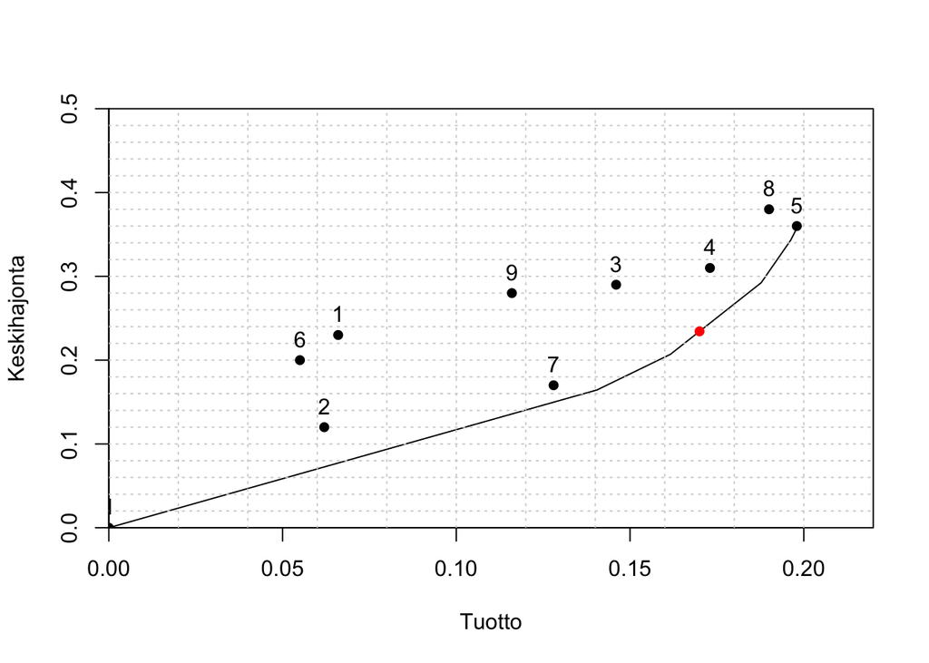

```r
plot(V~E, type="l", ylab="Keskihajonta", xlab="Tuotto",xlim=c(0,0.22), ylim=c(0,0.50), xaxs="i", yaxs="i")
grid(nx = 11, ny = 25, col = "lightgray", lty = "dotted")
asset_mu<-unlist(mu,use.names=FALSE)
asset_sd<-unlist(lapply(dat[,c(-1)],function(asset) round(sd(asset)*sqrt(17/18),2)), use.names=FALSE)
points(x=asset_mu,y=asset_sd,pch=16)
points(x = 0.17, y = (167/522)*V[4] + (1-167/522)*V[5], pch = 16, col="red")
asset_titles<-c(1:9)
text(x=asset_mu,y=asset_sd,labels=asset_titles,pos=3)
```

Kuvajaan on plotattu yksittäiset yhdeksän osaketta sekä punaisella tehokas 17% tuotto-odotuksen omaava kombinaatio. Kuvaja, kuten myös kulmaportfoliot, täsmäävät kirjan [3] (s. 20, 25) kanssa.

Koetin vielä tarkistaa tekemällä simulaation satunnaisista kombinaatioista (10000 kpl) ja laskemalla niille tuotto-keskihajonta parit ja plottaamalla ne edellisen kuvajan päälle. En näillä saanut tarpeeksi sellaisia kombinaatioita, missä osa painokertoimista olisi nollaa vaan keskittyvät yhteen kohtaan:

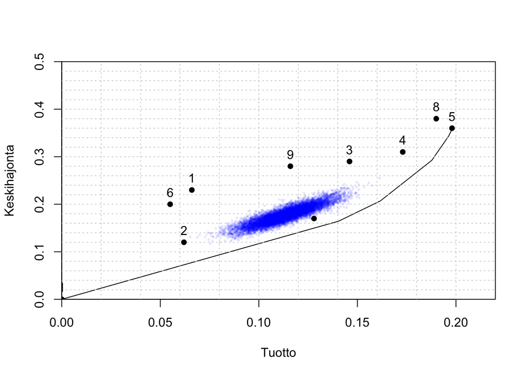

```r
par(mfrow=c(1, 1))
plot(V~E, type="l", ylab="Keskihajonta", xlab="Tuotto",xlim=c(0,0.22),ylim=c(0,0.50), xaxs="i", yaxs="i")
grid(nx = 11, ny = 25, col = "lightgray", lty = "dotted")
asset_mu<-unlist(mu,use.names=FALSE)
asset_sd<-unlist(lapply(dat[,c(-1)],function(asset) round(sd(asset)*sqrt(17/18),2)), use.names=FALSE)
points(x=asset_mu,y=asset_sd,pch=16)
asset_titles<-c(1:9)
text(x=asset_mu,y=asset_sd,labels=asset_titles,pos=3)
num_simulated_combinations<-10000
num_assets<-dim(mu)[1]
simulated_e<-list()
simulated_v<-list()
for (portfolio in 1:num_simulated_combinations) {
  X<-runif(num_assets)
  X<-as.matrix(X/sum(X),ncol=1)
  e<-t(X)%*%mu
  v<-sqrt(t(X)%*%C%*%X)
  simulated_e[[length(simulated_e)+1]]<-e
  simulated_v[[length(simulated_v)+1]]<-v
}
simulated_e<-unlist(simulated_e, use.names=FALSE)
simulated_v<-unlist(simulated_v, use.names=FALSE)
points(x=simulated_e,y=simulated_v,col=rgb(red=0,green=0,blue=1,alpha=0.1),pch='.',cex=3)
```

Mutta eivät ne ainakaan yli tehokkaan rintaman mene, eli sekin kertonee sitä, että toteutus toimii oikein.

## 5. Huomioitavaa

Tehokas rintama plotataan uudemmissa esityksissä siten, että tuotto on y-akselilla ja keskihajonta x-akselilla. Pidättäydyin tässä työssä Markowitzin tavassa. Uudemmissa esityksissä on mukana usein pääomamarkkinasuora, mutta se on 1950-luvun jälkeen syntynyttä teoriaa, ei MVA:n liittynyttä.

Koodin tämä versio (R hakemiston CLM.R tiedosto) kykenee käsittelemään 31 osaketta (ml. käteinen). Se tuottaa aina paljon debug-printtiä, joka auttaa seuraamaan miten totetus etenee. Se ei käsittele kirjassa mainittuja erikoistilanteita (kenties ei tarvitsekaan) ja ainoa rajoite mitä koodi tukee on $\sum \operatorname {X}_i=1$.

Ohjelma edellyttää, että R lisäosat hash ja lpSolve on asennettu install.packages() komennolla.

Olen ajatellut käyttäväni menetelmää siten, että plottaan omien osakkeitteni tehokkaan rintaman ja sijoitan oman salkkuni mukaan kuvajaan; se antaisi hieman näkemystä missä kohtaa tuotto-vaihtelu mahdollisuuksia salkku sijaitsee. Pohdittava asia on tietenkin, miltä aikaväliltä laskea tuotot ja varianssit.

## Lähteet

[1] Markowitz, H (1999) The Early History of Portfolio Theory: 1600–1960, Financial Analysts Journal, 55:4, 5-16, DOI: 10.2469/faj.v55.n4.2281.

[2] Markowitz, H. (1956), The optimization of a quadratic function subject to linear constraints. Naval Research Logistics, 3: 111-133. doi:10.1002/nav.3800030110

[3] Markowitz, H. M. (1959). Portfolio Selection: Efficient Diversification of Investments, Wiley, Yale University Press, 1970, 2nd ed. Basil Blackwell, 1991.

[4] Merton, R. C. (1972). An Analytic Derivation of the Efficient Portfolio Frontier. Journal of Financial and Quantitative Analysis, 7(4), 1851–1872. https://doi.org/10.2307/2329621

[5] Markowitz, H. (2012). The “Great Confusion” concerning MPT. Aestimatio (Madrid), 4, 8–27.

[6] Markowitz, H. (2014). Mean–variance approximations to expected utility. European Journal of Operational Research, 234(2), 346–355. https://doi.org/10.1016/j.ejor.2012.08.023